# Seoul Ddareungi: where bikes run short and where they pile up

STA3115 Final Project, Group 1 (exploratory analysis)

분석 기준: 2025년 1년 전체의 평일(공휴일 제외), 서울 25개 구 대여소 단위. 변수 정의는 `README.md` 참고. 2025년에 이용이 한 번도 없었던 대여소는 뺀다. 계절에 따라 결과가 달라지는지는 9절에서 월별로 확인한다.

**출근 품절(Y3 `am_empty`)은 출근 시간(6~10시)에 비가 오지 않은 평일만으로 계산한다.** 대여소마다 가장 가까운 기상청 관측소의 시간 강수를 쓴다(`scripts/10_aggregate_dry.py`). 비를 빼기 전 값은 `am_empty_all`로 남겨 11절에서 비교한다. 대여소 역할도 이 기준으로 다시 나눈다. 월별 분석(9절)은 전체 평일 기준이다.

```r
rd <- function(f) read_csv(f, col_types = cols(station_no = col_character(), adm_cd = col_character()))
dry <- rd("../data/stations_dry.csv")
stations <- rd("../data/stations.csv") %>%
  filter(use_day > 0) %>%
  rename(am_empty_all = am_empty) %>%
  inner_join(dry %>% select(station_no, am_empty = am_empty_dry, pm_empty = pm_empty_dry, climb_in_m), by = "station_no") %>%
  inner_join(rd("../data/station_terrain.csv") %>% select(station_no, slope_cop = slope_r300), by = "station_no") %>%
  inner_join(rd("../data/station_terrain_bare.csv") %>% select(station_no, elev_bare_m, slope_bare = slope_bare_r300), by = "station_no") %>%
  inner_join(rd("../data/station_climb_bare.csv") %>% select(station_no, climb_bare = climb_bare_all), by = "station_no") %>%
  left_join(rd("../data/station_dong.csv") %>% select(station_no, res_index), by = "station_no") %>%
  left_join(rd("../data/stations_wet.csv") %>% select(station_no, am_empty_wet, n_wet), by = "station_no") %>%
  mutate(log_use = log(use_day),
         elev_band = cut(elev_m, c(0, 20, 40, Inf), labels = c("<20 m", "20-40 m", ">=40 m"), right = FALSE),
         gap = as.integer(am_empty >= 0.3))
# roles with the dry-morning shortage (same thresholds as scripts/06: bottom 20% of use, another station within 300 m)
q20 <- sort(stations$use_day)[floor(nrow(stations) * 0.2) + 1]
q50 <- sort(stations$use_day)[floor(nrow(stations) * 0.5) + 1]
stations <- stations %>%
  mutate(low_near = use_day <= q20 & nearest_station_m <= 300,
         role = case_when(low_near & gap == 1 ~ "supply_gap_suspect", low_near ~ "consolidate", gap == 1 ~ "morning_gap",
                          use_day >= q50 & commute_share >= 0.5 ~ "commute_core", TRUE ~ "other"),
         role = factor(role, levels = c("commute_core", "consolidate", "supply_gap_suspect", "morning_gap", "other")))
monthly <- read_csv("../data/monthly_age.csv")
district_hour <- read_csv("../data/district_hour.csv") %>% filter(gu != "(미상)")
station_month <- read_csv("../data/station_month.csv", col_types = cols(station_no = col_character())) %>%
  inner_join(stations %>% select(station_no, elev_m, subway_m, univ_m, docks, gu), by = "station_no") %>%
  filter(use_day > 0)
coverage <- read_csv("../data/coverage_2025.csv")
coverage
```

| month | od_days | od_weekdays | inv_days | inv_weekdays | inv_stations | inv_days_with_24_hours |
| --- | --- | --- | --- | --- | --- | --- |
| 1 | 31 | 18 | 29 | 16 | 2766 | 28 |
| 2 | 28 | 20 | 28 | 20 | 2766 | 27 |
| 3 | 31 | 20 | 31 | 20 | 2766 | 31 |
| 4 | 30 | 22 | 30 | 22 | 2774 | 30 |
| 5 | 31 | 20 | 31 | 20 | 2778 | 31 |
| 6 | 30 | 19 | 30 | 19 | 2780 | 30 |
| 7 | 31 | 23 | 31 | 23 | 2784 | 31 |
| 8 | 31 | 20 | 31 | 20 | 2792 | 31 |
| 9 | 30 | 22 | 30 | 22 | 2798 | 29 |
| 10 | 31 | 18 | 31 | 18 | 2799 | 30 |

[output cut: 2 more lines]

```r
nrow(stations)
```

```
## [1] 2713
```

# 1. Current state: who is riding

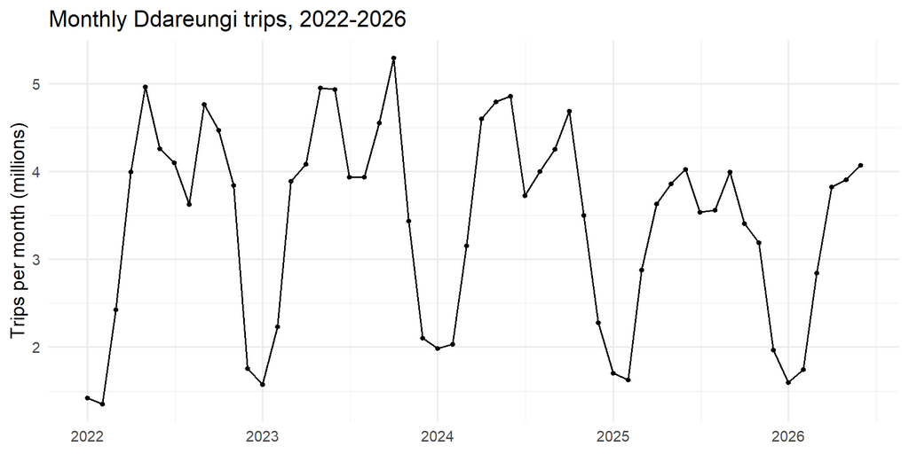

```r
monthly %>%
  group_by(month) %>% summarise(trips = sum(trips)) %>%
  mutate(date = as.Date(paste0(month, "-01"))) %>%
  ggplot(aes(date, trips / 1e6)) +
  geom_line() + geom_point(size = 1) +
  labs(x = NULL, y = "Trips per month (millions)", title = "Monthly Ddareungi trips, 2022-2026")
```

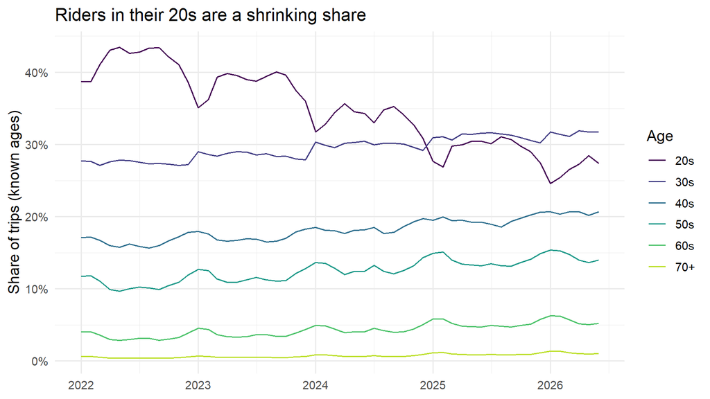

```r
monthly %>%
  filter(age %in% c("20대", "30대", "40대", "50대", "60대", "70대이상")) %>%
  mutate(age = recode(age, "20대" = "20s", "30대" = "30s", "40대" = "40s", "50대" = "50s",
                      "60대" = "60s", "70대이상" = "70+")) %>%
  group_by(month) %>% mutate(share = trips / sum(trips)) %>% ungroup() %>%
  mutate(date = as.Date(paste0(month, "-01"))) %>%
  ggplot(aes(date, share, colour = age)) +
  geom_line() +
  scale_y_continuous(labels = scales::percent) +
  scale_colour_viridis_d(end = 0.9) +
  labs(x = NULL, y = "Share of trips (known ages)", colour = "Age",
       title = "Riders in their 20s are a shrinking share")
```

```r
monthly %>%
  mutate(year = substr(month, 1, 4)) %>%
  filter(year %in% c("2023", "2024", "2025")) %>%
  group_by(year) %>% summarise(trips = sum(trips))
```

| year | trips |
| --- | --- |
| 2023 | 44904665 |
| 2024 | 43849559 |
| 2025 | 37373054 |

# 2. Scale: bikes parked vs bikes in use (Unit 1, 3)

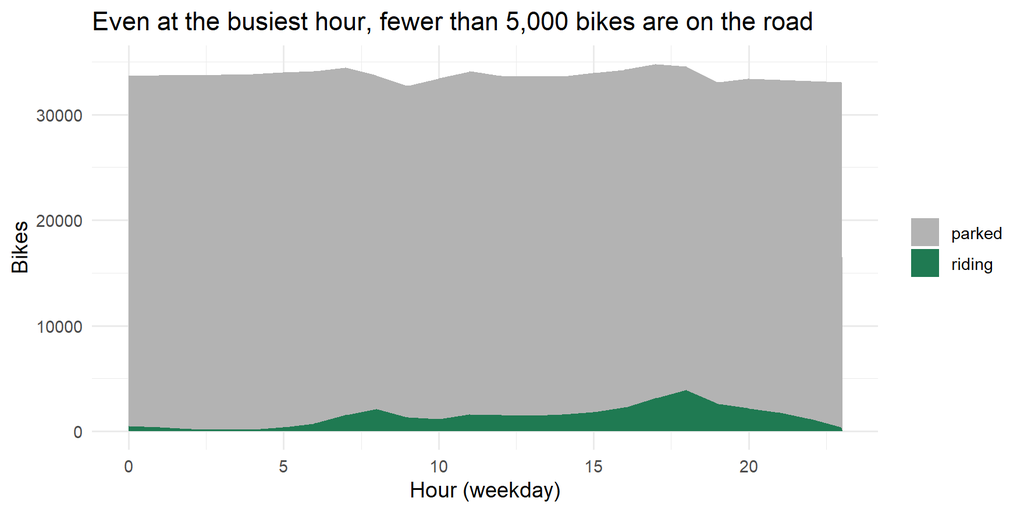

```r
district_hour %>%
  group_by(hour) %>% summarise(parked = sum(parked), riding = sum(riding)) %>%
  pivot_longer(-hour) %>%
  ggplot(aes(hour, value, fill = name)) +
  geom_area() +
  scale_fill_manual(values = c(parked = "grey70", riding = "#1f7a52")) +
  labs(x = "Hour (weekday)", y = "Bikes", fill = NULL,
       title = "Even at the busiest hour, fewer than 5,000 bikes are on the road")
```

# 3. Distribution of use and transformation (Units 3-5)

이용량은 오른쪽으로 길게 치우쳐 있어 로그 변환 후 비교한다.

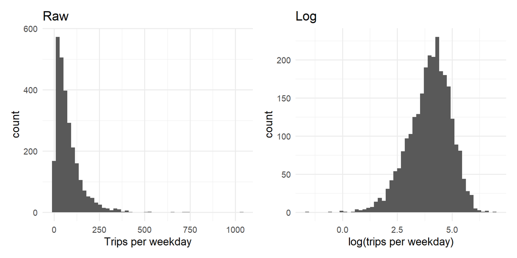

```r
p1 <- ggplot(stations, aes(use_day)) + geom_histogram(bins = 50) + labs(x = "Trips per weekday", title = "Raw")
p2 <- ggplot(stations, aes(log_use)) + geom_histogram(bins = 50) + labs(x = "log(trips per weekday)", title = "Log")
patchwork::wrap_plots(p1, p2)
```

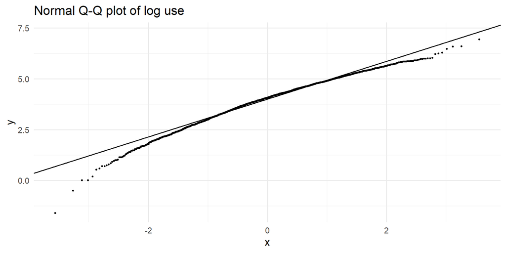

```r
ggplot(stations, aes(sample = log_use)) + stat_qq(size = 0.6) + stat_qq_line() +
  labs(title = "Normal Q-Q plot of log use")
```

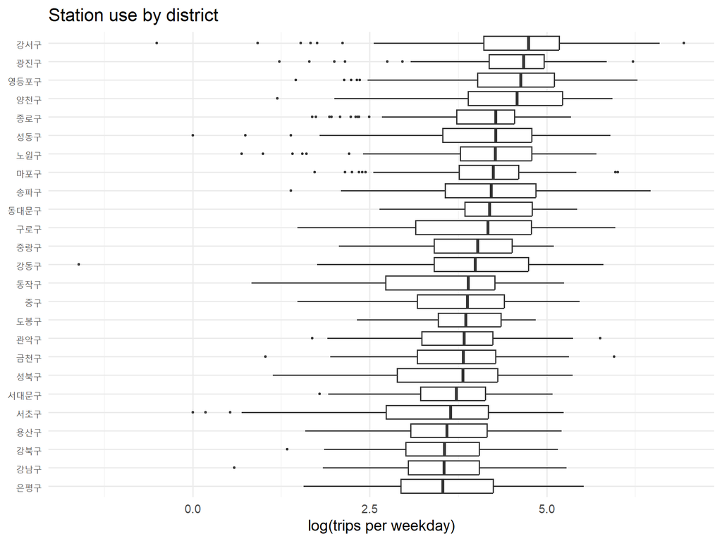

```r
stations %>%
  mutate(gu = fct_reorder(gu, log_use, median)) %>%
  ggplot(aes(log_use, gu)) +
  geom_boxplot(outlier.size = 0.6) +
  labs(x = "log(trips per weekday)", y = NULL, title = "Station use by district")
```

# 4. Elevation and drift: LOESS (Units 7-8)

Y2 `net_day` = 반납 − 대여. 음수면 자전거가 빠져나가는 대여소.

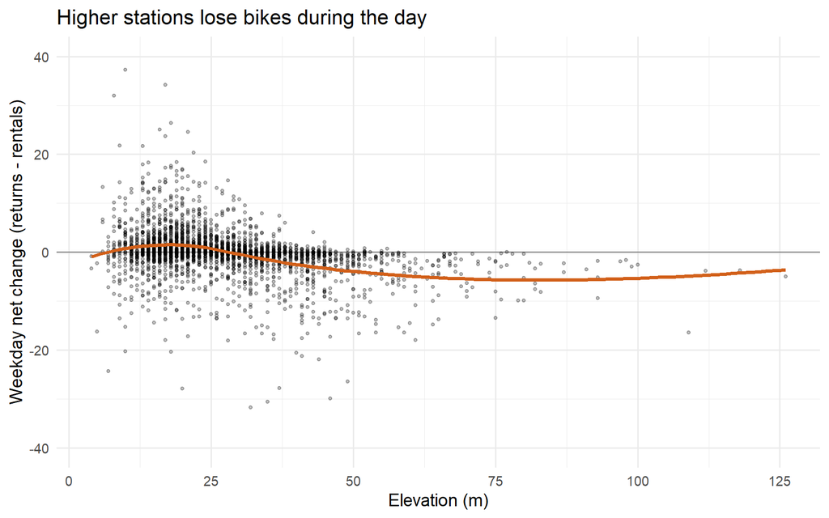

```r
fit_net <- loess(net_day ~ elev_m, data = stations, span = 0.75)
ggplot(stations, aes(elev_m, net_day)) +
  geom_hline(yintercept = 0, colour = "grey60") +
  geom_point(alpha = 0.25, size = 0.8) +
  geom_smooth(method = "loess", span = 0.75, se = FALSE, colour = "#d2601a") +
  coord_cartesian(ylim = c(-40, 40)) +
  labs(x = "Elevation (m)", y = "Weekday net change (returns - rentals)",
       title = "Higher stations lose bikes during the day")
```

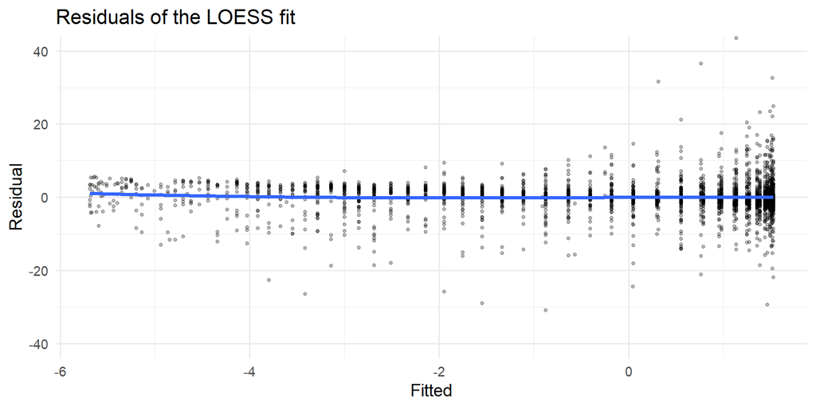

```r
stations %>% mutate(fitted = fitted(fit_net), resid = residuals(fit_net)) %>%
  ggplot(aes(fitted, resid)) + geom_point(alpha = 0.25, size = 0.8) +
  geom_smooth(method = "loess", se = FALSE) +
  coord_cartesian(ylim = c(-40, 40)) +
  labs(x = "Fitted", y = "Residual", title = "Residuals of the LOESS fit")
```

Y3 `am_empty` = 출근 시간(6~10시)에 비가 오지 않은 평일의 7~9시 재고 기록 중 0대 비율.

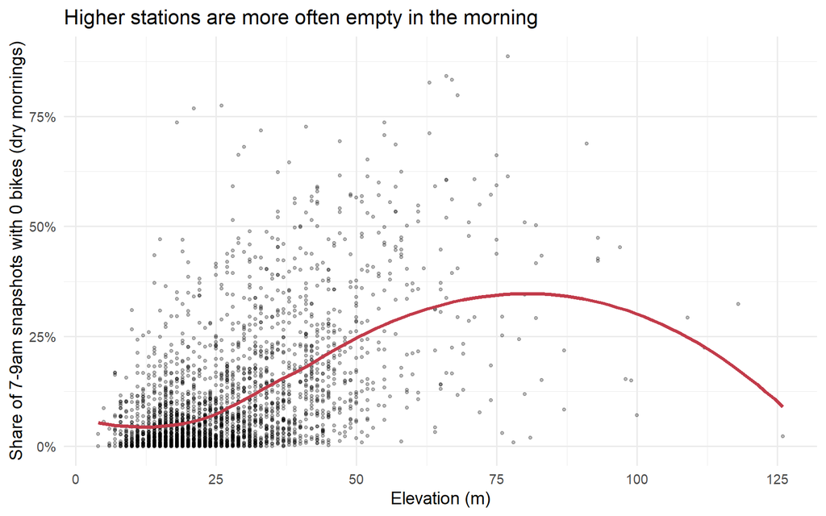

```r
ggplot(stations, aes(elev_m, am_empty)) +
  geom_point(alpha = 0.25, size = 0.8) +
  geom_smooth(method = "loess", span = 0.75, se = FALSE, colour = "#c23b4a") +
  scale_y_continuous(labels = scales::percent) +
  labs(x = "Elevation (m)", y = "Share of 7-9am snapshots with 0 bikes (dry mornings)",
       title = "Higher stations are more often empty in the morning")
```

```r
stations %>% group_by(elev_band) %>%
  summarise(stations = n(), mean_am_empty = mean(am_empty, na.rm = TRUE), mean_net = mean(net_day))
```

| elev_band | stations | mean_am_empty | mean_net |
| --- | --- | --- | --- |
| <20 m | 944 | 0.04778708 | 1.27940678 |
| 20-40 m | 1290 | 0.09528062 | 0.01875969 |
| >=40 m | 479 | 0.25084760 | -3.66058455 |

# 5. Conditioning on subway access: coplot (Units 9-10)

```r
q_sub <- quantile(stations$subway_m, c(0, 0.25, 0.5, 0.75, 1))
sub_labels <- c(sprintf("Subway <= %d m", round(q_sub[2])),
                sprintf("%d-%d m", round(q_sub[2]), round(q_sub[3])),
                sprintf("%d-%d m", round(q_sub[3]), round(q_sub[4])),
                sprintf("> %d m", round(q_sub[4])))
stations <- stations %>%
  mutate(subway_group = cut(subway_m, q_sub, labels = sub_labels, include.lowest = TRUE))
```

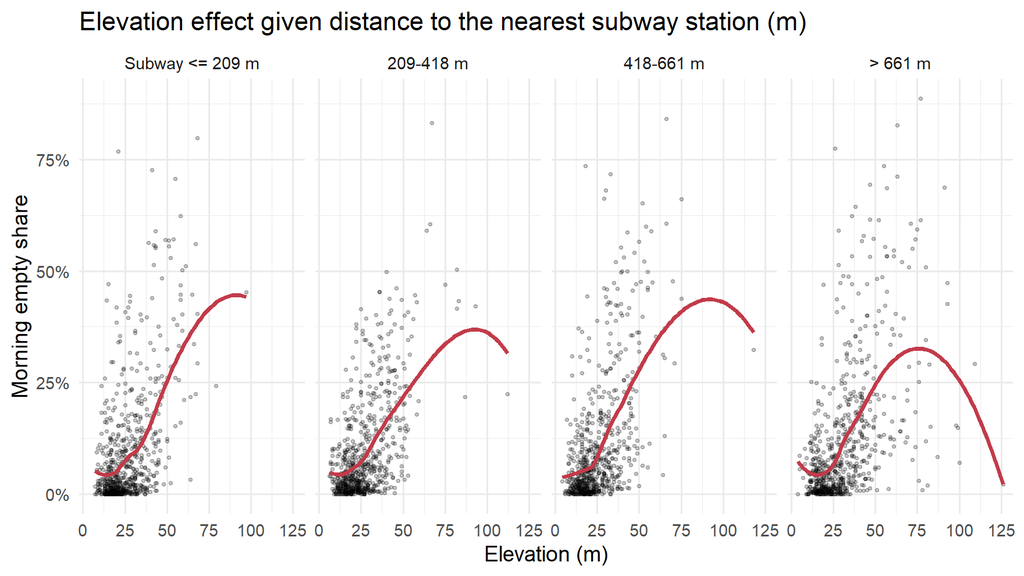

```r
stations %>%
  ggplot(aes(elev_m, am_empty)) +
  geom_point(alpha = 0.2, size = 0.7) +
  geom_smooth(method = "loess", se = FALSE, colour = "#c23b4a") +
  facet_wrap(~ subway_group, nrow = 1) +
  scale_y_continuous(labels = scales::percent) +
  labs(x = "Elevation (m)", y = "Morning empty share",
       title = "Elevation effect given distance to the nearest subway station (m)")
```

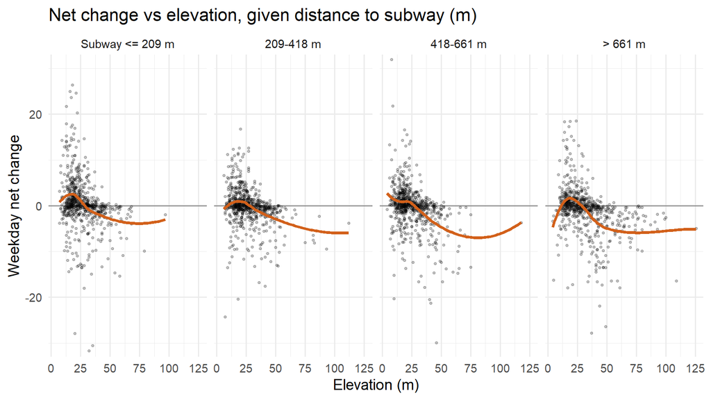

```r
stations %>%
  ggplot(aes(elev_m, net_day)) +
  geom_hline(yintercept = 0, colour = "grey60") +
  geom_point(alpha = 0.2, size = 0.7) +
  geom_smooth(method = "loess", se = FALSE, colour = "#d2601a") +
  facet_wrap(~ subway_group, nrow = 1) +
  coord_cartesian(ylim = c(-30, 30)) +
  labs(x = "Elevation (m)", y = "Weekday net change",
       title = "Net change vs elevation, given distance to subway (m)")
```

# 6. Where on the map: level plot (Unit 11)

정류소 좌표에 LOESS 곡면을 맞춰 격자 위에 그린다. 대여소에서 1km 넘게 떨어진 격자는 지운다.

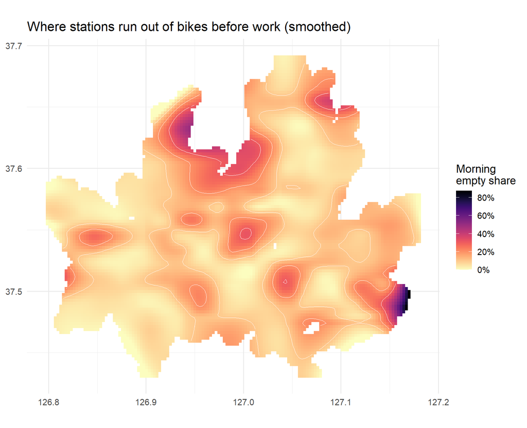

```r
fit_map <- loess(am_empty ~ lon * lat, data = stations, span = 0.05, degree = 2)
grid <- expand_grid(lon = seq(min(stations$lon), max(stations$lon), length.out = 140),
                    lat = seq(min(stations$lat), max(stations$lat), length.out = 110))
km <- function(lat1, lon1, lat2, lon2) {
  6371 * 2 * asin(sqrt(sin((lat2 - lat1) * pi / 360)^2 +
                       cos(lat1 * pi / 180) * cos(lat2 * pi / 180) * sin((lon2 - lon1) * pi / 360)^2))
}
grid$near <- map2_dbl(grid$lat, grid$lon, ~ min(km(.x, .y, stations$lat, stations$lon)))
grid <- grid %>% filter(near <= 1) %>%
  mutate(fit = pmin(pmax(predict(fit_map, newdata = .), 0), 1))
ggplot(grid, aes(lon, lat)) +
  geom_raster(aes(fill = fit)) +
  geom_contour(aes(z = fit), breaks = c(0.1, 0.2, 0.3), colour = "white", linewidth = 0.3) +
  scale_fill_viridis(option = "magma", direction = -1, labels = scales::percent, na.value = NA) +
  coord_quickmap() +
  labs(x = NULL, y = NULL, fill = "Morning\nempty share",
       title = "Where stations run out of bikes before work (smoothed)")
```

# 7. Which stations run empty: logistic regression (Units 12-13)

결과 변수: 출근 시간 품절이 잦은 대여소(`gap` = `am_empty` 0.3 이상). 설명변수: 고도(10m 단위), 지하철역과 대학까지 거리(로그), 거치대 수.

```r
stations_lr <- stations %>% filter(!is.na(gap)) %>%
  mutate(elev10 = elev_m / 10, log2_subway = log2(subway_m), log2_univ = log2(univ_m))
fit_lr <- glm(gap ~ elev10 + log2_subway + log2_univ + docks, family = binomial, data = stations_lr)
tidy(fit_lr, exponentiate = TRUE, conf.int = TRUE) %>% mutate(across(where(is.numeric), ~ round(.x, 3)))
```

| term | estimate | std.error | statistic | p.value | conf.low | conf.high |
| --- | --- | --- | --- | --- | --- | --- |
| (Intercept) | 0.016 | 0.810 | -5.080 | 0.000 | 0.003 | 0.079 |
| elev10 | 2.097 | 0.047 | 15.647 | 0.000 | 1.914 | 2.305 |
| log2_subway | 0.968 | 0.049 | -0.663 | 0.508 | 0.880 | 1.067 |
| log2_univ | 1.036 | 0.065 | 0.547 | 0.585 | 0.914 | 1.178 |
| docks | 0.939 | 0.019 | -3.291 | 0.001 | 0.904 | 0.974 |

```r
mean(stations_lr$gap)
```

```
## [1] 0.09841504
```

고도의 효과가 지하철역과의 거리에 따라 달라지는지(상호작용) 확인한다. coplot에서 역 가까운 구간의 곡선이 더 가팔랐다.

```r
fit_lr2 <- glm(gap ~ elev10 * log2_subway + log2_univ + docks, family = binomial, data = stations_lr)
anova(fit_lr, fit_lr2, test = "Chisq")
```

|  | Resid. Df | Resid. Dev | Df | Deviance | Pr(>Chi) |
| --- | --- | --- | --- | --- | --- |
| 1 | 2708 | 1374.518 | NA | NA | NA |
| 2 | 2707 | 1351.323 | 1 | 23.19536 | 1.463503e-06 |

```r
tidy(fit_lr2, exponentiate = TRUE, conf.int = TRUE) %>% mutate(across(where(is.numeric), ~ round(.x, 3)))
```

| term | estimate | std.error | statistic | p.value | conf.low | conf.high |
| --- | --- | --- | --- | --- | --- | --- |
| (Intercept) | 0.000 | 1.504 | -6.511 | 0.000 | 0.000 | 0.001 |
| elev10 | 8.113 | 0.299 | 7.005 | 0.000 | 4.570 | 14.771 |
| log2_subway | 1.789 | 0.144 | 4.040 | 0.000 | 1.357 | 2.387 |
| log2_univ | 1.056 | 0.065 | 0.837 | 0.403 | 0.931 | 1.202 |
| docks | 0.943 | 0.019 | -3.086 | 0.002 | 0.907 | 0.977 |
| elev10:log2_subway | 0.859 | 0.032 | -4.707 | 0.000 | 0.806 | 0.915 |

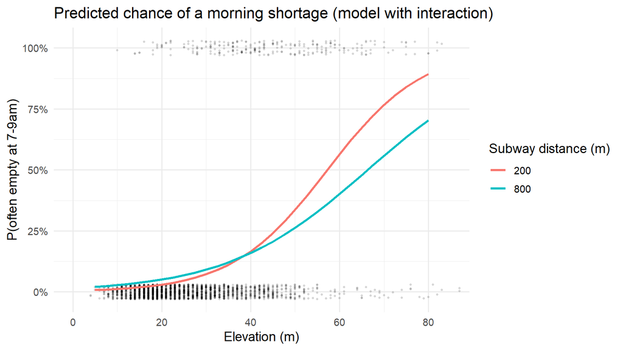

```r
newd <- expand_grid(elev10 = seq(0.5, 8, by = 0.25), log2_subway = log2(c(200, 800)),
                    log2_univ = median(stations_lr$log2_univ), docks = median(stations_lr$docks))
newd$p <- predict(fit_lr2, newdata = newd, type = "response")
ggplot(newd, aes(elev10 * 10, p, colour = factor(round(2^log2_subway)))) +
  geom_jitter(data = stations_lr, aes(elev_m, gap), inherit.aes = FALSE,
              height = 0.03, width = 0, alpha = 0.1, size = 0.6) +
  geom_line(linewidth = 1) +
  scale_y_continuous(labels = scales::percent) +
  coord_cartesian(xlim = c(0, 85)) +
  labs(x = "Elevation (m)", y = "P(often empty at 7-9am)", colour = "Subway distance (m)",
       title = "Predicted chance of a morning shortage (model with interaction)")
```

로지스틱 모형 점검: 예측 확률 구간별로 실제 비율을 비교한다(binned plot).

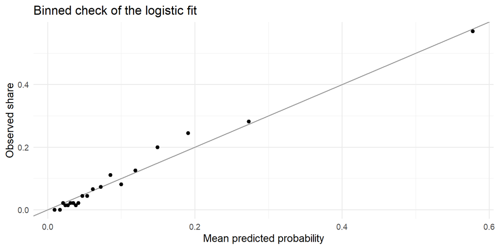

```r
stations_lr %>% mutate(p = fitted(fit_lr), bin = ntile(p, 20)) %>%
  group_by(bin) %>% summarise(p = mean(p), observed = mean(gap), n = n()) %>%
  ggplot(aes(p, observed)) + geom_abline(colour = "grey60") + geom_point() +
  labs(x = "Mean predicted probability", y = "Observed share", title = "Binned check of the logistic fit")
```

기준값(품절 비율 30%)을 바꿔도 결론이 같은지 확인한다.

```r
map_dfr(c(0.2, 0.3, 0.4), function(cut) {
  dat <- stations_lr %>% mutate(gap = as.integer(am_empty >= cut))
  glm(gap ~ elev10 + log2_subway + log2_univ + docks, family = binomial, data = dat) %>%
    tidy(exponentiate = TRUE, conf.int = TRUE) %>%
    filter(term != "(Intercept)") %>%
    mutate(threshold = cut, share_gap = mean(dat$gap))
}) %>%
  select(threshold, share_gap, term, estimate, conf.low, conf.high, p.value) %>%
  mutate(across(where(is.numeric), ~ round(.x, 3)))
```

| threshold | share_gap | term | estimate | conf.low | conf.high | p.value |
| --- | --- | --- | --- | --- | --- | --- |
| 0.2 | 0.176 | elev10 | 2.301 | 2.110 | 2.516 | 0.000 |
| 0.2 | 0.176 | log2_subway | 0.924 | 0.855 | 0.998 | 0.044 |
| 0.2 | 0.176 | log2_univ | 1.024 | 0.925 | 1.135 | 0.650 |
| 0.2 | 0.176 | docks | 0.949 | 0.923 | 0.975 | 0.000 |
| 0.3 | 0.098 | elev10 | 2.097 | 1.914 | 2.305 | 0.000 |
| 0.3 | 0.098 | log2_subway | 0.968 | 0.880 | 1.067 | 0.508 |
| 0.3 | 0.098 | log2_univ | 1.036 | 0.914 | 1.178 | 0.585 |
| 0.3 | 0.098 | docks | 0.939 | 0.904 | 0.974 | 0.001 |
| 0.4 | 0.058 | elev10 | 2.080 | 1.877 | 2.316 | 0.000 |
| 0.4 | 0.058 | log2_subway | 0.923 | 0.821 | 1.042 | 0.187 |

[output cut: 2 more lines]

# 8. Station roles and elevation: mosaic plot (Unit 14, optional)

```r
roles_short <- c(commute_core = "Commute core", consolidate = "Consolidate",
                 supply_gap_suspect = "Supply gap?", morning_gap = "Morning gap", other = "Other")
tab <- with(stations, table(Role = factor(roles_short[as.character(role)], levels = roles_short),
                            `Elevation (m)` = factor(elev_band, labels = c("<20", "20-40", "40+"))))
tab
```

```
##               Elevation (m)
## Role           <20 20-40 40+
##   Commute core 291   112  14
##   Consolidate   62   140  97
##   Supply gap?    6    27  95
##   Morning gap    6    69  64
##   Other        579   942 209
```

```r
chisq.test(tab)
```

```
##
##  Pearson's Chi-squared test
##
## data:  tab
## X-squared = 720.06, df = 8, p-value < 2.2e-16
```

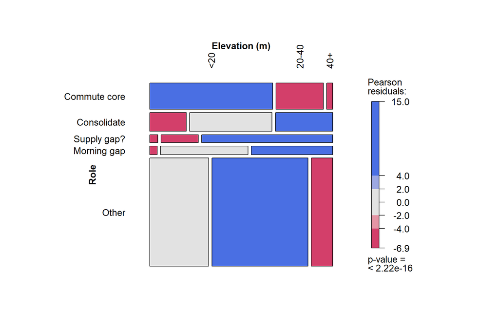

```r
mosaic(tab, shade = TRUE, legend = TRUE,
       labeling_args = list(rot_labels = c(left = 0, top = 90), just_labels = c(left = "right", top = "left"),
                            offset_labels = c(left = 1.2, top = 0.3), offset_varnames = c(left = 3.2, top = 1.4)),
       margins = c(left = 6, top = 4))
```

# 9. Does the pattern hold all year?

한 달만 보면 계절의 영향을 구분할 수 없으므로, 월별로 같은 관계를 다시 계산한다.

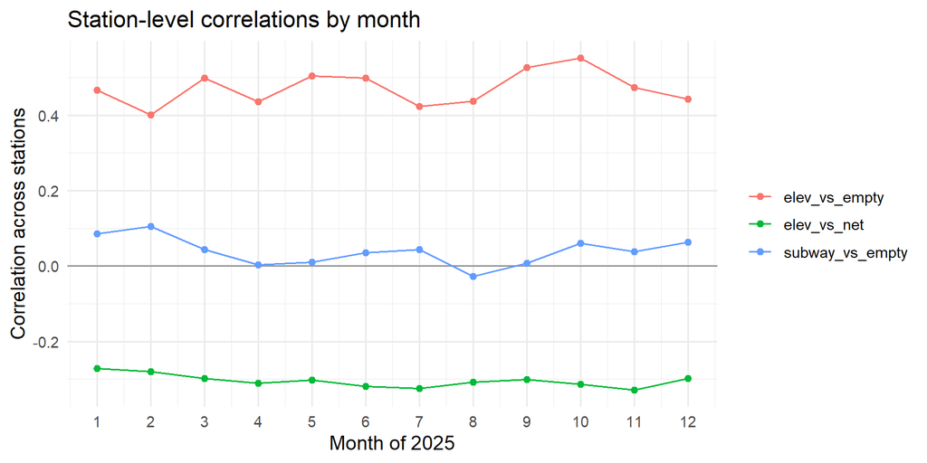

```r
station_month %>%
  group_by(month) %>%
  summarise(stations = n(),
            elev_vs_empty = cor(elev_m, am_empty, use = "complete.obs"),
            elev_vs_net = cor(elev_m, net_day),
            subway_vs_empty = cor(log(subway_m), am_empty, use = "complete.obs")) %>%
  pivot_longer(-c(month, stations)) %>%
  ggplot(aes(month, value, colour = name)) +
  geom_hline(yintercept = 0, colour = "grey60") +
  geom_line() + geom_point() +
  scale_x_continuous(breaks = 1:12) +
  labs(x = "Month of 2025", y = "Correlation across stations", colour = NULL,
       title = "Station-level correlations by month")
```

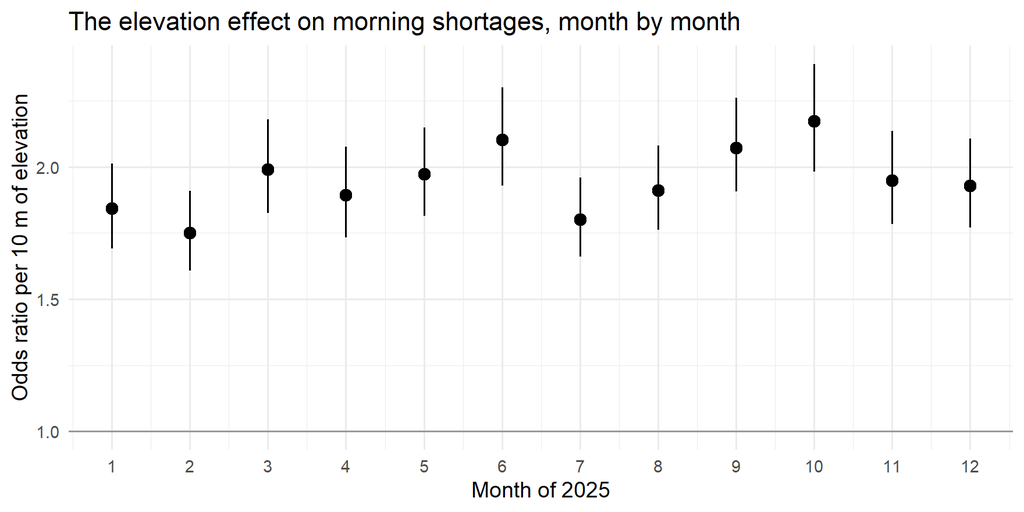

```r
station_month %>%
  filter(!is.na(am_empty)) %>%
  mutate(gap = as.integer(am_empty >= 0.3), elev10 = elev_m / 10,
         log2_subway = log2(subway_m), log2_univ = log2(univ_m)) %>%
  group_by(month) %>%
  group_modify(~ glm(gap ~ elev10 + log2_subway + log2_univ + docks, family = binomial, data = .x) %>%
                 tidy(exponentiate = TRUE, conf.int = TRUE)) %>%
  filter(term == "elev10") %>%
  ggplot(aes(month, estimate)) +
  geom_hline(yintercept = 1, colour = "grey60") +
  geom_pointrange(aes(ymin = conf.low, ymax = conf.high)) +
  scale_x_continuous(breaks = 1:12) +
  labs(x = "Month of 2025", y = "Odds ratio per 10 m of elevation",
       title = "The elevation effect on morning shortages, month by month")
```

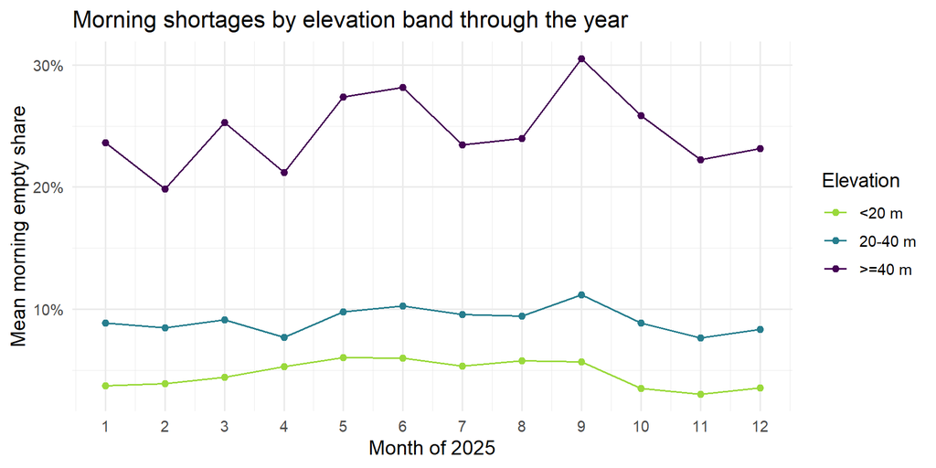

```r
station_month %>%
  mutate(elev_band = cut(elev_m, c(0, 20, 40, Inf), labels = c("<20 m", "20-40 m", ">=40 m"), right = FALSE)) %>%
  group_by(month, elev_band) %>%
  summarise(am_empty = mean(am_empty, na.rm = TRUE), .groups = "drop") %>%
  ggplot(aes(month, am_empty, colour = elev_band)) +
  geom_line() + geom_point() +
  scale_x_continuous(breaks = 1:12) +
  scale_y_continuous(labels = scales::percent) +
  scale_colour_viridis_d(end = 0.85, direction = -1) +
  labs(x = "Month of 2025", y = "Mean morning empty share", colour = "Elevation",
       title = "Morning shortages by elevation band through the year")
```

# 10. Height or steepness? Residual dependence and coplot (Units 7-10)

질문: 품절은 대여소가 높은 곳에 있어서인가, 주변이 가팔라서인가? 경사는 대여소 주변 300m 평균 경사로, 건물이 빠진 지표면 고도(서울시 1:5000 등고선, `scripts/12_dem_contour.R`)에서 계산한다. 오르막(`climb_bare`)은 이 대여소에 도착한 평일 이용이 출발지보다 평균 몇 m 높이 올라왔는가이다(`analysis/bare_compare.R`).

먼저 세 지형 변수끼리의 관계를 본다.

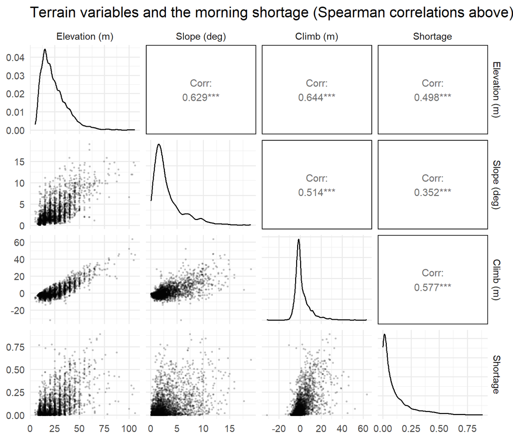

```r
GGally::ggpairs(stations %>% select(`Elevation (m)` = elev_bare_m, `Slope (deg)` = slope_bare, `Climb (m)` = climb_bare,
                                    `Shortage` = am_empty),
                lower = list(continuous = GGally::wrap("points", alpha = 0.15, size = 0.4)),
                upper = list(continuous = GGally::wrap("cor", method = "spearman", size = 3.5))) +
  labs(title = "Terrain variables and the morning shortage (Spearman correlations above)")
```

고도로 품절을 LOESS 적합한 뒤, 남은 잔차가 경사나 오르막과 함께 움직이는지 본다(residual dependence plot). 경사가 고도와 따로 중요하다면 잔차가 경사를 따라 올라가야 한다.

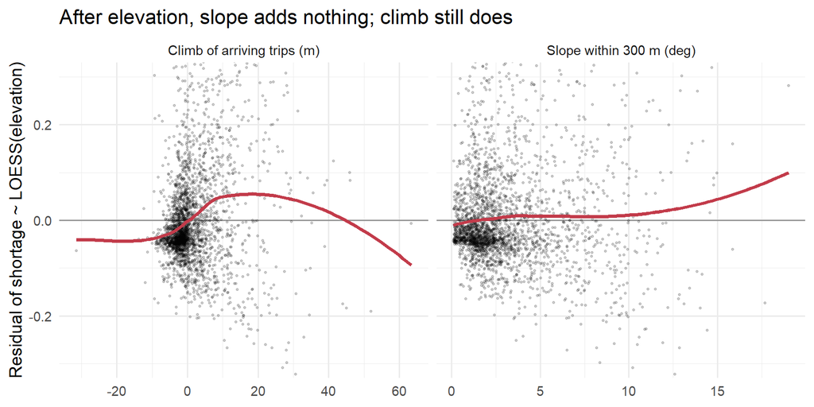

```r
fit_elev <- loess(am_empty ~ elev_bare_m, data = stations, span = 0.75)
res_d <- stations %>% mutate(resid = residuals(fit_elev)) %>%
  select(resid, `Slope within 300 m (deg)` = slope_bare, `Climb of arriving trips (m)` = climb_bare) %>%
  pivot_longer(-resid)
ggplot(res_d, aes(value, resid)) +
  geom_hline(yintercept = 0, colour = "grey60") +
  geom_point(alpha = 0.15, size = 0.6) +
  geom_smooth(method = "loess", span = 0.75, se = FALSE, colour = "#c23b4a") +
  facet_wrap(~ name, scales = "free_x") +
  coord_cartesian(ylim = c(-0.3, 0.3)) +
  labs(x = NULL, y = "Residual of shortage ~ LOESS(elevation)",
       title = "After elevation, slope adds nothing; climb still does")
```

같은 질문을 coplot으로: 고도 구간 안에서 경사와 품절의 관계.

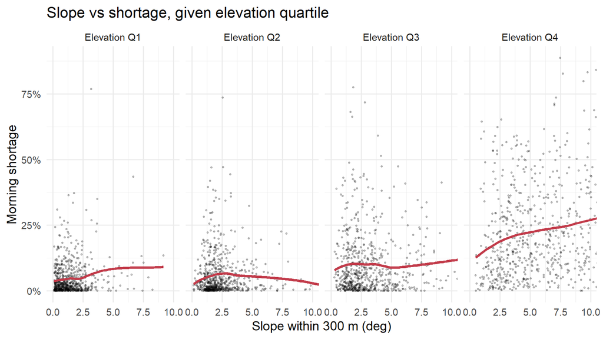

```r
stations %>%
  mutate(elev_group = cut(elev_bare_m, quantile(elev_bare_m, c(0, .25, .5, .75, 1)), include.lowest = TRUE,
                          labels = paste0("Elevation ", c("Q1", "Q2", "Q3", "Q4")))) %>%
  ggplot(aes(slope_bare, am_empty)) +
  geom_point(alpha = 0.2, size = 0.6) +
  geom_smooth(method = "loess", se = FALSE, colour = "#c23b4a") +
  facet_wrap(~ elev_group, nrow = 1) +
  scale_y_continuous(labels = scales::percent) + coord_cartesian(xlim = c(0, 10)) +
  labs(x = "Slope within 300 m (deg)", y = "Morning shortage", title = "Slope vs shortage, given elevation quartile")
```

로지스틱 회귀로 같은 비교(AIC가 낮을수록 잘 설명). 건물이 섞인 Copernicus 경사도 함께 본다.

```r
d_t <- stations %>% filter(!is.na(am_empty)) %>%
  mutate(l_sub = log2(subway_m), l_uni = log2(univ_m))
terms <- c("(none)" = "1", "slope, surface model" = "slope_cop", "slope, bare earth" = "slope_bare",
           "elevation, 90 m" = "elev_m", "elevation, bare earth" = "elev_bare_m", "climb, bare earth" = "climb_bare",
           "elevation + slope" = "elev_bare_m + slope_bare", "elevation + climb" = "elev_bare_m + climb_bare")
tibble(model = names(terms),
       AIC = map_dbl(terms, ~ AIC(glm(as.formula(paste("gap ~ l_sub + l_uni + docks +", .x)), family = binomial, data = d_t)))) %>%
  mutate(AIC = round(AIC, 1)) %>% arrange(AIC)
```

| model | AIC |
| --- | --- |
| elevation + climb | 1324.3 |
| climb, bare earth | 1334.9 |
| elevation, bare earth | 1361.2 |
| elevation + slope | 1362.6 |
| elevation, 90 m | 1384.5 |
| slope, bare earth | 1547.6 |
| slope, surface model | 1580.1 |
| (none) | 1689.8 |

```r
glm(gap ~ scale(elev_bare_m) + scale(slope_bare) + l_sub + l_uni + docks, family = binomial, data = d_t) %>%
  tidy(exponentiate = TRUE, conf.int = TRUE) %>% filter(grepl("scale", term)) %>% mutate(across(where(is.numeric), ~ round(.x, 3)))
```

| term | estimate | std.error | statistic | p.value | conf.low | conf.high |
| --- | --- | --- | --- | --- | --- | --- |
| scale(elev_bare_m) | 3.17 | 0.092 | 12.485 | 0.000 | 2.653 | 3.812 |
| scale(slope_bare) | 0.94 | 0.083 | -0.745 | 0.456 | 0.797 | 1.105 |

# 11. Is it the weather? Wet vs dry mornings, Tukey mean-difference plot (Units 3, 6)

출근 시간에 비가 오면 아침 대여가 크게 준다(`analysis/weather_checks_log.txt`). 품절이 그날 수요 때문이라면 비 오는 아침에는 고지대 품절도 크게 줄어야 한다. 대여소마다 비 온 출근 시간과 비 오지 않은 출근 시간의 품절을 비교한다.

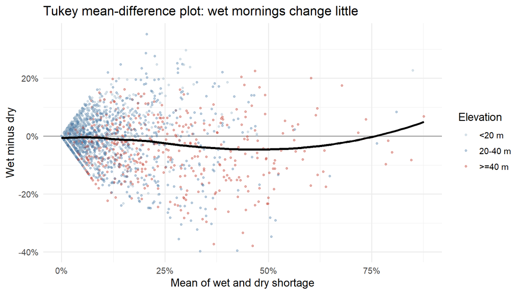

```r
md <- stations %>% filter(n_wet >= 30, !is.na(am_empty_wet)) %>%
  mutate(mean_wd = (am_empty + am_empty_wet) / 2, diff_wd = am_empty_wet - am_empty)
ggplot(md, aes(mean_wd, diff_wd)) +
  geom_hline(yintercept = 0, colour = "grey60") +
  geom_point(aes(colour = elev_band), alpha = 0.35, size = 0.8) +
  geom_smooth(method = "loess", se = FALSE, colour = "black") +
  scale_colour_manual(values = c("<20 m" = "#9fb7c9", "20-40 m" = "#4f7ea8", ">=40 m" = "#c0392b")) +
  scale_x_continuous(labels = scales::percent) + scale_y_continuous(labels = scales::percent) +
  labs(x = "Mean of wet and dry shortage", y = "Wet minus dry", colour = "Elevation",
       title = "Tukey mean-difference plot: wet mornings change little")
```

```r
md %>% group_by(elev_band) %>%
  summarise(stations = n(), dry = mean(am_empty), wet = mean(am_empty_wet), mean_diff = mean(diff_wd),
            cor_wet_dry = cor(am_empty, am_empty_wet)) %>% mutate(across(where(is.double), ~ round(.x, 3)))
```

| elev_band | stations | dry | wet | mean_diff | cor_wet_dry |
| --- | --- | --- | --- | --- | --- |
| <20 m | 924 | 0.047 | 0.054 | 0.007 | 0.742 |
| 20-40 m | 1283 | 0.095 | 0.083 | -0.012 | 0.759 |
| >=40 m | 477 | 0.251 | 0.209 | -0.043 | 0.854 |

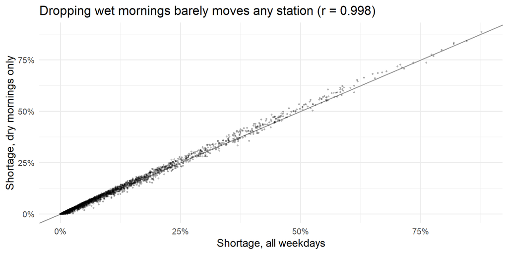

```r
ggplot(stations, aes(am_empty_all, am_empty)) +
  geom_abline(colour = "grey60") + geom_point(alpha = 0.2, size = 0.6) +
  scale_x_continuous(labels = scales::percent) + scale_y_continuous(labels = scales::percent) +
  labs(x = "Shortage, all weekdays", y = "Shortage, dry mornings only",
       title = sprintf("Dropping wet mornings barely moves any station (r = %.3f)",
                       cor(stations$am_empty_all, stations$am_empty, use = "complete")))
```

# 12. Is it because hills are residential? Coplot on a residential index (Units 9-10)

서울 생활인구(행정동, 2026년 6~7월 평일)로 동마다 새벽(2~4시) 인구 ÷ 낮(13~15시) 인구를 계산해 대여소에 붙였다 (`scripts/14_living_population.py`). 1보다 크면 낮에 사람이 빠져나가는 주거지다.

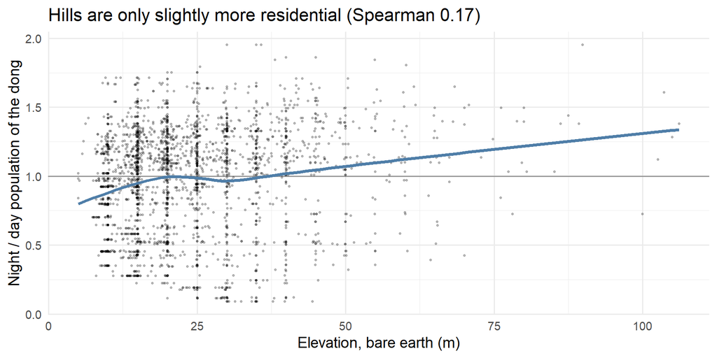

```r
ggplot(stations %>% filter(!is.na(res_index)), aes(elev_bare_m, res_index)) +
  geom_hline(yintercept = 1, colour = "grey60") +
  geom_point(alpha = 0.2, size = 0.6) +
  geom_smooth(method = "loess", se = FALSE, colour = "#4f7ea8") +
  labs(x = "Elevation, bare earth (m)", y = "Night / day population of the dong",
       title = sprintf("Hills are only slightly more residential (Spearman %.2f)",
                       cor(stations$elev_bare_m, stations$res_index, method = "spearman", use = "complete")))
```

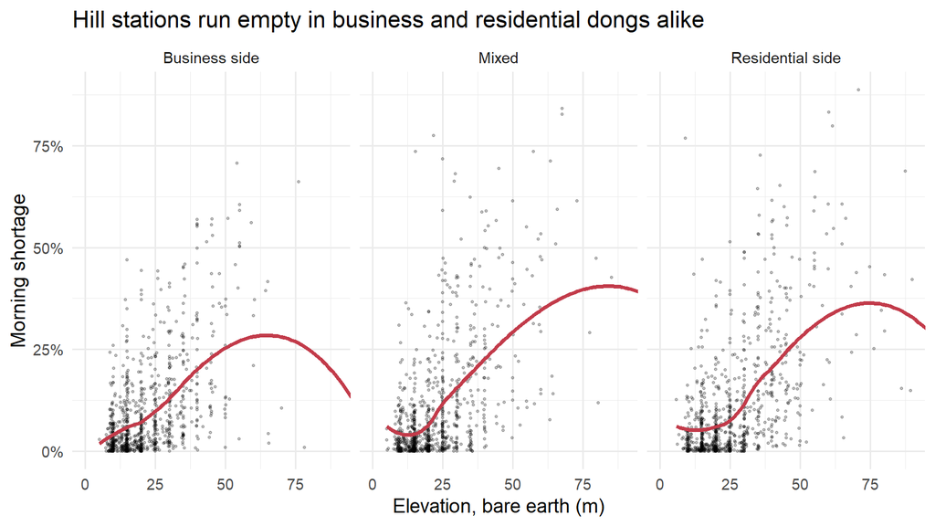

```r
stations %>% filter(!is.na(res_index)) %>%
  mutate(res_group = cut(res_index, quantile(res_index, c(0, 1/3, 2/3, 1)), include.lowest = TRUE,
                         labels = c("Business side", "Mixed", "Residential side"))) %>%
  ggplot(aes(elev_bare_m, am_empty)) +
  geom_point(alpha = 0.2, size = 0.6) +
  geom_smooth(method = "loess", se = FALSE, colour = "#c23b4a") +
  facet_wrap(~ res_group, nrow = 1) +
  scale_y_continuous(labels = scales::percent) + coord_cartesian(xlim = c(0, 90)) +
  labs(x = "Elevation, bare earth (m)", y = "Morning shortage",
       title = "Hill stations run empty in business and residential dongs alike")
```

# 13. District level: flat districts ride more (Unit 7)

25개 구의 평균 경사(대여소 주변 300m, 지표면)와 대여소당 평일 대여. 구가 25개뿐이고 평평한 구는 대부분 한강변이라 참고로만 본다.

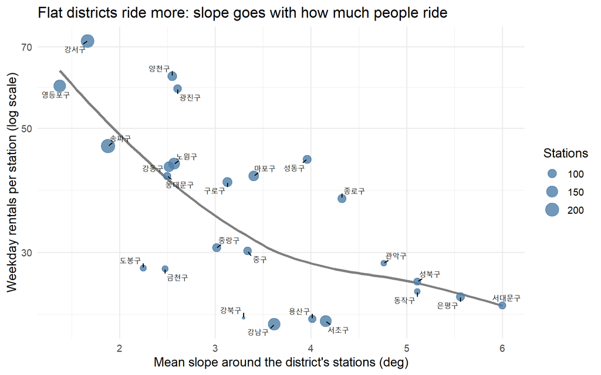

```r
gu_t <- read_csv("../data/gu_terrain.csv")
ggplot(gu_t, aes(slope_bare, rent_per_station)) +
  geom_smooth(method = "loess", span = 0.9, se = FALSE, colour = "grey50") +
  geom_point(aes(size = stations), colour = "#4f7ea8", alpha = 0.8) +
  ggrepel::geom_text_repel(aes(label = gu), size = 3, seed = 1, min.segment.length = 0.2) +
  scale_y_log10() +
  labs(x = "Mean slope around the district's stations (deg)", y = "Weekday rentals per station (log scale)",
       size = "Stations", title = "Flat districts ride more: slope goes with how much people ride")
```

```r
cor.test(gu_t$slope_bare, gu_t$rent_per_station, method = "spearman")
```

```
##
##  Spearman's rank correlation rho
##
## data:  gu_t$slope_bare and gu_t$rent_per_station
## S = 4270, p-value = 0.0007125
## alternative hypothesis: true rho is not equal to 0
## sample estimates:
##        rho
## -0.6423077
```